# Baby Basic Eye Gaze (study2children)

Adam Stone, PhD

02-09-2018

# Starting Out

```r
# Import data that's been cleaned up from 01importclean
data <- read_feather("cleanedbabyeyedata.feather")
```

[output not shown]

Next, let’s do boxplots of each AOI across all stories and kids, grouping for forward vs. reversed.

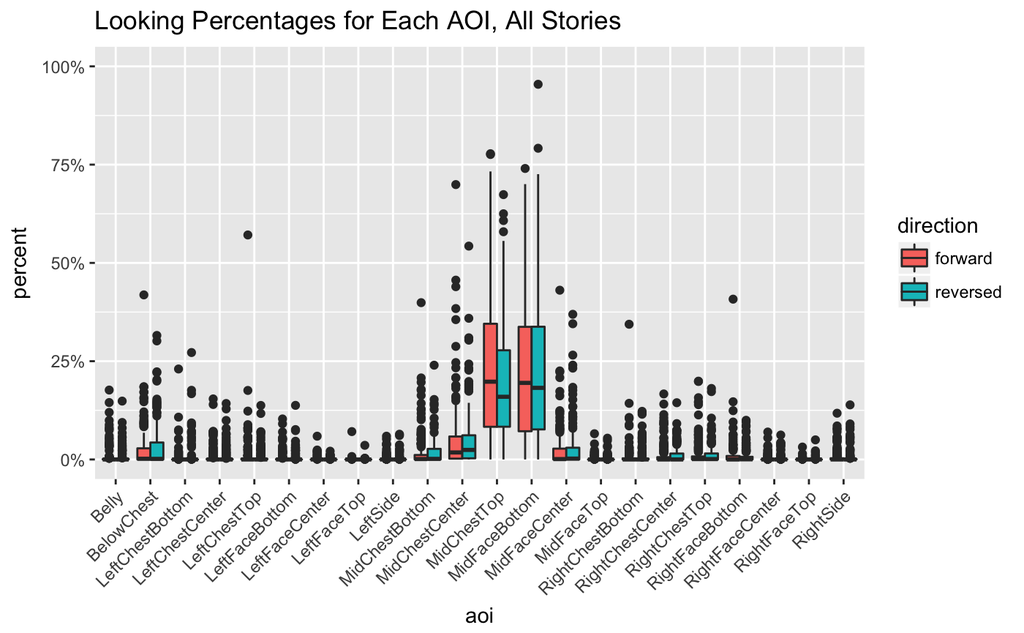

```r
# Boxplot!
ggplot(data, aes(x = aoi, y = percent, fill = direction)) +
  geom_boxplot() + theme(axis.text.x = element_text(angle=45, hjust = 1)) +
  ggtitle("Looking Percentages for Each AOI, All Stories") +
  scale_y_continuous(labels = scales::percent, limits = c(0,1))
```

Looks like by far most of the activity is along the Mid** AOIs. Let’s look closer.

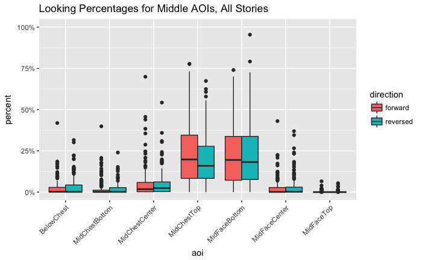

```r
data_mid <- data %>%
  filter(str_detect(aoi,"Mid") | aoi == "BelowChest")
ggplot(data_mid, aes(x = aoi, y = percent, fill = direction)) +
  geom_boxplot() + theme(axis.text.x = element_text(angle=45, hjust = 1)) +
  ggtitle("Looking Percentages for Middle AOIs, All Stories") +
  scale_y_continuous(labels = scales::percent, limits = c(0,1))
```

As a preliminary analysis I’m going to just look at MidChestTop and MidFaceBottom. Are there differences based on direction, group, or age for either AOI?

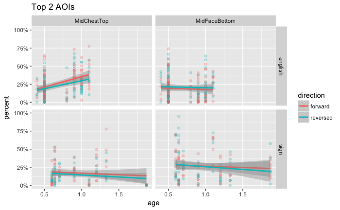

```r
data_mid %>%
  filter(aoi == "MidChestTop" | aoi == "MidFaceBottom") %>%
  ggplot(aes(x = age, y = percent, color = direction)) + geom_point(alpha = 0.25) +
  geom_smooth(method = "lm") + facet_grid(language ~ aoi) +
  scale_y_continuous(labels = scales::percent, limits = c(0,1)) +
  ggtitle("Top 2 AOIs")
```

What if we defined a Face-Chest Ratio (FCR) such that:

1. MidFaceCenter, MidFaceBottom = Face
2. MidChestTop, MidChestCenter, MidChestBottom, BelowChest = Chest
3. FCR = face - chest / face + chest

Let’s try that. Let’s also try only MidFaceBottom vs. MidChestTop too, and call that MFCR (for middle of middle).

CHart belows suggests group differences and that CODA babies have a trend to more face-looking while NSE babies don’t.

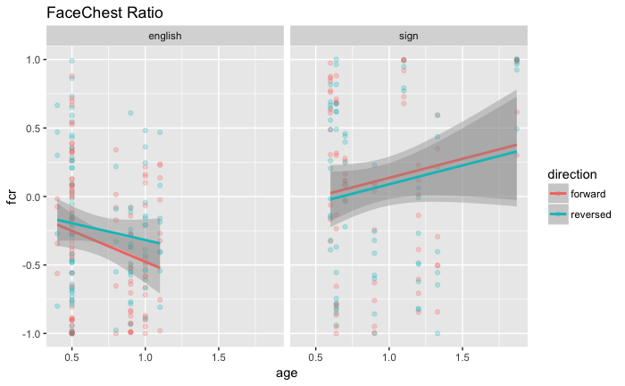

```r
data_mid <- data_mid %>%
  select(-secs, -hits) %>%
  spread(aoi,percent) %>%
  group_by(participant, trial) %>%
  mutate(face = sum(MidFaceCenter, MidFaceBottom, na.rm = TRUE),
         chest = sum(MidChestTop, MidChestCenter, MidChestBottom, BelowChest, na.rm = TRUE),
         fcr = (face - chest) / (face + chest),
         mfcr = (MidFaceBottom - MidChestTop) / (MidFaceBottom + MidChestTop))
ggplot(data_mid, aes(x = age, y = fcr, color = direction)) + geom_point(alpha = 0.25) +
  geom_smooth(method = "lm") + facet_wrap("language") + ggtitle("FaceChest Ratio")
```

Let’s also check out MFCR (a stricter ratio). Almost the same thing.

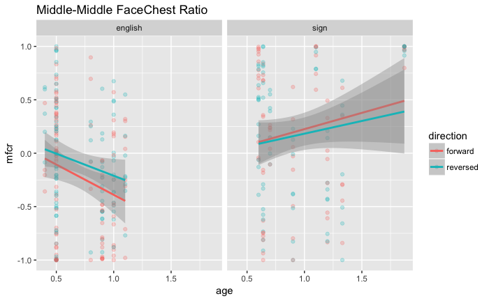

```r
ggplot(data_mid, aes(x = age, y = mfcr, color = direction)) + geom_point(alpha = 0.25) +
  geom_smooth(method = "lm") + facet_wrap("language") + ggtitle("Middle-Middle FaceChest Ratio")
```

So this is rad! Such obvious group differences should also be reflected in a heat map that is collapsed across age and direction. And the heat map below shows that CODAs really focus on the MidFaceBottom AOI, while English-exposed children are a bit more spread out, looking much more at the chest.

# Heat Maps

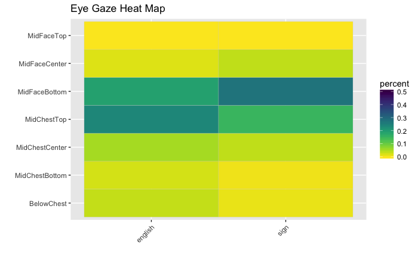

```r
data_mid_heat <- data_mid %>%
  ungroup() %>%
  select(-face, -chest, -fcr, -mfcr) %>%
  gather(aoi, percent, BelowChest:MidFaceTop) %>%
  group_by(language, participant, direction, aoi) %>%
  summarise(percent = mean(percent, na.rm = TRUE)) %>%
  group_by(language, direction, aoi) %>%
  summarise(percent = mean(percent, na.rm = TRUE)) %>%
  group_by(language, aoi) %>%
  summarise(percent = mean(percent, na.rm = TRUE)) %>%
  mutate(aoi = factor(aoi, levels = c("BelowChest", "MidChestBottom", "MidChestCenter", "MidChestTop",
                                      "MidFaceBottom", "MidFaceCenter", "MidFaceTop")))
ggplot(data_mid_heat, aes(x = language, y = aoi)) +
  geom_tile(aes(fill=percent),color="lightgray",na.rm=TRUE) +
  scale_fill_viridis(option = "viridis", direction=-1, limits = c(0,.5)) +
  theme(axis.text.x=element_text(angle=45,hjust=1)) +
  ylab("") + xlab("") + ggtitle("Eye Gaze Heat Map")
```

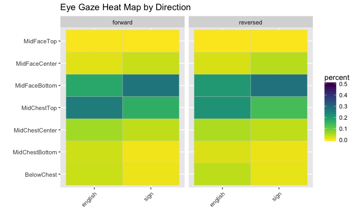

```r
data_mid_heat <- data_mid %>%
  ungroup() %>%
  select(-face, -chest, -fcr, -mfcr) %>%
  gather(aoi, percent, BelowChest:MidFaceTop) %>%
  group_by(language, participant, direction, aoi) %>%
  summarise(percent = mean(percent, na.rm = TRUE)) %>%
  group_by(language, direction, aoi) %>%
  summarise(percent = mean(percent, na.rm = TRUE)) %>%
  mutate(aoi = factor(aoi, levels = c("BelowChest", "MidChestBottom", "MidChestCenter", "MidChestTop",
                                      "MidFaceBottom", "MidFaceCenter", "MidFaceTop")))
ggplot(data_mid_heat, aes(x = language, y = aoi)) +
  geom_tile(aes(fill=percent),color="lightgray",na.rm=TRUE) +
  scale_fill_viridis(option = "viridis", direction=-1, limits = c(0,.5)) +
  theme(axis.text.x=element_text(angle=45,hjust=1)) +
  ylab("") + xlab("") + ggtitle("Eye Gaze Heat Map by Direction") + facet_wrap("direction")
```

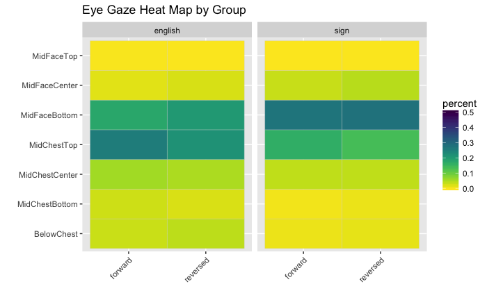

```r
ggplot(data_mid_heat, aes(x = direction, y = aoi)) +
  geom_tile(aes(fill=percent),color="lightgray",na.rm=TRUE) +
  scale_fill_viridis(option = "viridis", direction=-1, limits = c(0,.5)) +
  theme(axis.text.x=element_text(angle=45,hjust=1)) +
  ylab("") + xlab("") + ggtitle("Eye Gaze Heat Map by Group") + facet_wrap("language")
```

# Statistical Testing of FCR/mFCR

Now that we’ve found something interesting with FCR and mFCR, let’s see if it holds up in stats modeling.

## Language, Direction, & Age Predictors

```r
fcr_lmm <- lmer(fcr ~ age + language * direction + (1|story) + (1|participant), data = data_mid)
fcr_lmm_babies <- fcr_lmm
summary(fcr_lmm)
```

```
Linear mixed model fit by REML t-tests use Satterthwaite approximations to degrees of freedom [lmerMod]
Formula: fcr ~ age + language * direction + (1 | story) + (1 | participant)
   Data: data_mid

REML criterion at convergence: 397.3

Scaled residuals:
     Min       1Q   Median       3Q      Max
-2.32591 -0.70238  0.01949  0.61683  2.40740

Random effects:
 Groups      Name        Variance Std.Dev.
 participant (Intercept) 0.182324 0.42699
 story       (Intercept) 0.007847 0.08858
 Residual                0.143056 0.37823
Number of obs: 343, groups:  participant, 26; story, 8

Fixed effects:
                                Estimate Std. Error        df t value Pr(>|t|)
(Intercept)                     -0.37458    0.22608  24.58000  -1.657   0.1103
age                              0.04596    0.28077  22.95000   0.164   0.8714
languagesign                     0.47782    0.19696  24.93000   2.426   0.0228 *
directionreversed                0.11512    0.05346 312.00000   2.153   0.0321 *
languagesign:directionreversed  -0.13617    0.08359 308.83000  -1.629   0.1043
---
Signif. codes:  0 ‘***’ 0.001 ‘**’ 0.01 ‘*’ 0.05 ‘.’ 0.1 ‘ ’ 1

Correlation of Fixed Effects:
            (Intr) age    lnggsg drctnr
age         -0.855
languagesgn  0.040 -0.383
dirctnrvrsd -0.112 -0.001  0.128
lnggsgn:drc  0.071  0.001 -0.208 -0.632
```

Let’s repeat the LMM with outcome mFCR.

```r
mfcr_lmm <- lmer(mfcr ~ age + language * direction + (1|story) + (1|participant), data = data_mid)
summary(mfcr_lmm)
```

```
Linear mixed model fit by REML t-tests use Satterthwaite approximations to degrees of freedom [lmerMod]
Formula: mfcr ~ age + language * direction + (1 | story) + (1 | participant)
   Data: data_mid

REML criterion at convergence: 456.6

Scaled residuals:
     Min       1Q   Median       3Q      Max
-2.46925 -0.61593  0.03207  0.62477  2.46665

Random effects:
 Groups      Name        Variance Std.Dev.
 participant (Intercept) 0.176292 0.41987
 story       (Intercept) 0.008741 0.09349
 Residual                0.173802 0.41690
Number of obs: 342, groups:  participant, 26; story, 8

Fixed effects:
                                Estimate Std. Error        df t value Pr(>|t|)
(Intercept)                     -0.20796    0.22465  24.85000  -0.926   0.3635
age                             -0.01009    0.27813  22.92000  -0.036   0.9714
languagesign                     0.44903    0.19604  25.38000   2.290   0.0306 *
directionreversed                0.15127    0.05905 311.15000   2.562   0.0109 *
languagesign:directionreversed  -0.16326    0.09222 307.90000  -1.770   0.0777 .
---
Signif. codes:  0 ‘***’ 0.001 ‘**’ 0.01 ‘*’ 0.05 ‘.’ 0.1 ‘ ’ 1

Correlation of Fixed Effects:
            (Intr) age    lnggsg drctnr
age         -0.852
languagesgn  0.036 -0.380
dirctnrvrsd -0.123 -0.002  0.142
lnggsgn:drc  0.078  0.002 -0.231 -0.633
```

## Direction & Language Predictors

In the LMMs we’ve run so far, age is always the worst predictor. What happens if we take it out?

```r
fcr_lmm_noage <- lmer(fcr ~ direction * language + (1|story) + (1|participant), data = data_mid)
summary(fcr_lmm_noage)
```

```
Linear mixed model fit by REML t-tests use Satterthwaite approximations to degrees of freedom [lmerMod]
Formula: fcr ~ direction * language + (1 | story) + (1 | participant)
   Data: data_mid

REML criterion at convergence: 396.6

Scaled residuals:
     Min       1Q   Median       3Q      Max
-2.32362 -0.70579  0.01901  0.61677  2.40572

Random effects:
 Groups      Name        Variance Std.Dev.
 participant (Intercept) 0.174468 0.41769
 story       (Intercept) 0.007863 0.08867
 Residual                0.143052 0.37822
Number of obs: 343, groups:  participant, 26; story, 8

Fixed effects:
                                Estimate Std. Error        df t value Pr(>|t|)
(Intercept)                     -0.34295    0.11522  30.00000  -2.977  0.00572 **
directionreversed                0.11505    0.05346 312.03000   2.152  0.03215 *
languagesign                     0.49009    0.17840  26.64000   2.747  0.01065 *
directionreversed:languagesign  -0.13622    0.08358 308.86000  -1.630  0.10417
---
Signif. codes:  0 ‘***’ 0.001 ‘**’ 0.01 ‘*’ 0.05 ‘.’ 0.1 ‘ ’ 1

Correlation of Fixed Effects:
            (Intr) drctnr lnggsg
dirctnrvrsd -0.221
languagesgn -0.598  0.141
drctnrvrsd:  0.141 -0.632 -0.230
```

The mFCR LMM gives us similar results.

```r
mfcr_lmm_noage <- lmer(mfcr ~ direction * language + (1|story) + (1|participant), data = data_mid)
summary(mfcr_lmm_noage)
```

```
Linear mixed model fit by REML t-tests use Satterthwaite approximations to degrees of freedom [lmerMod]
Formula: mfcr ~ direction * language + (1 | story) + (1 | participant)
   Data: data_mid

REML criterion at convergence: 455.8

Scaled residuals:
     Min       1Q   Median       3Q      Max
-2.46344 -0.61631  0.03143  0.62647  2.46435

Random effects:
 Groups      Name        Variance Std.Dev.
 participant (Intercept) 0.168361 0.4103
 story       (Intercept) 0.008762 0.0936
 Residual                0.173797 0.4169
Number of obs: 342, groups:  participant, 26; story, 8

Fixed effects:
                                Estimate Std. Error        df t value Pr(>|t|)
(Intercept)                     -0.21495    0.11534  30.85000  -1.864   0.0719 .
directionreversed                0.15117    0.05905 311.18000   2.560   0.0109 *
languagesign                     0.44626    0.17771  27.26000   2.511   0.0183 *
directionreversed:languagesign  -0.16330    0.09221 307.93000  -1.771   0.0776 .
---
Signif. codes:  0 ‘***’ 0.001 ‘**’ 0.01 ‘*’ 0.05 ‘.’ 0.1 ‘ ’ 1

Correlation of Fixed Effects:
            (Intr) drctnr lnggsg
dirctnrvrsd -0.243
languagesgn -0.595  0.156
drctnrvrsd:  0.155 -0.633 -0.254
```

## Language as only predictor

Suppose we only looked at language.

```r
fcr_lmm_langonly <- lmer(fcr ~  language + (1|story) + (1|participant) + (1|direction), data = data_mid)
summary(fcr_lmm_langonly)
```

```
Linear mixed model fit by REML t-tests use Satterthwaite approximations to degrees of freedom [lmerMod]
Formula: fcr ~ language + (1 | story) + (1 | participant) + (1 | direction)
   Data: data_mid

REML criterion at convergence: 393.3

Scaled residuals:
     Min       1Q   Median       3Q      Max
-2.40807 -0.69476  0.01355  0.62402  2.51558

Random effects:
 Groups      Name        Variance  Std.Dev.
 participant (Intercept) 0.1740925 0.41724
 story       (Intercept) 0.0078550 0.08863
 direction   (Intercept) 0.0009377 0.03062
 Residual                0.1438342 0.37925
Number of obs: 343, groups:  participant, 26; story, 8; direction, 2

Fixed effects:
             Estimate Std. Error      df t value Pr(>|t|)
(Intercept)   -0.2872     0.1143 25.5250  -2.512   0.0187 *
languagesign   0.4240     0.1735 23.9100   2.444   0.0223 *
---
Signif. codes:  0 ‘***’ 0.001 ‘**’ 0.01 ‘*’ 0.05 ‘.’ 0.1 ‘ ’ 1

Correlation of Fixed Effects:
            (Intr)
languagesgn -0.586
```

Forward only.

```r
fcr_lmm_langonly_f <- lmer(fcr ~  language + (1|story) + (1|participant), data = filter(data_mid,direction=="forward"))
summary(fcr_lmm_langonly_f)
```

```
Linear mixed model fit by REML t-tests use Satterthwaite approximations to degrees of freedom [lmerMod]
Formula: fcr ~ language + (1 | story) + (1 | participant)
   Data: filter(data_mid, direction == "forward")

REML criterion at convergence: 205.5

Scaled residuals:
    Min      1Q  Median      3Q     Max
-2.2975 -0.6143  0.0585  0.5775  2.4350

Random effects:
 Groups      Name        Variance Std.Dev.
 participant (Intercept) 0.19064  0.4366
 story       (Intercept) 0.02856  0.1690
 Residual                0.12219  0.3496
Number of obs: 175, groups:  participant, 26; story, 8

Fixed effects:
             Estimate Std. Error      df t value Pr(>|t|)
(Intercept)   -0.3534     0.1294 27.1060  -2.732   0.0109 *
languagesign   0.5060     0.1844 23.5770   2.744   0.0114 *
---
Signif. codes:  0 ‘***’ 0.001 ‘**’ 0.01 ‘*’ 0.05 ‘.’ 0.1 ‘ ’ 1

Correlation of Fixed Effects:
            (Intr)
languagesgn -0.549
```

Reversed only.

```r
fcr_lmm_langonly_r <- lmer(fcr ~  language + (1|story) + (1|participant), data = filter(data_mid,direction=="reversed"))
summary(fcr_lmm_langonly_r)
```

```
Linear mixed model fit by REML t-tests use Satterthwaite approximations to degrees of freedom [lmerMod]
Formula: fcr ~ language + (1 | story) + (1 | participant)
   Data: filter(data_mid, direction == "reversed")

REML criterion at convergence: 218.5

Scaled residuals:
     Min       1Q   Median       3Q      Max
-2.11980 -0.65284 -0.07479  0.55081  2.44230

Random effects:
 Groups      Name        Variance Std.Dev.
 participant (Intercept) 0.15664  0.39578
 story       (Intercept) 0.00908  0.09529
 Residual                0.15008  0.38741
Number of obs: 168, groups:  participant, 26; story, 8

Fixed effects:
             Estimate Std. Error      df t value Pr(>|t|)
(Intercept)   -0.2202     0.1122 26.6790  -1.964   0.0601 .
languagesign   0.3438     0.1713 23.5130   2.007   0.0564 .
---
Signif. codes:  0 ‘***’ 0.001 ‘**’ 0.01 ‘*’ 0.05 ‘.’ 0.1 ‘ ’ 1

Correlation of Fixed Effects:
            (Intr)
languagesgn -0.594
```

# Figures

First an error bar chart.

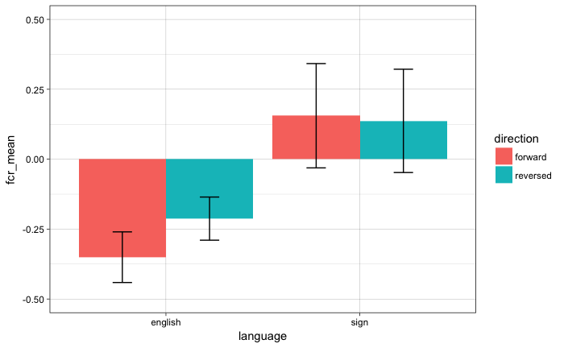

```r
data_mid_error_baby <- data_mid %>%
  group_by(language, direction, participant) %>%
  summarise(fcr = mean(fcr)) %>%
  group_by(language, direction) %>%
  summarise(fcr_mean = mean(fcr),
            sd = sd(fcr),
            n = n(),
            se = sd/sqrt(n))
ggplot(data_mid_error_baby, aes(x = language, y = fcr_mean, fill = direction)) +
  geom_bar(stat = "identity", position = position_dodge()) +
  geom_errorbar(aes(ymin = fcr_mean-se, ymax = fcr_mean+se), position = position_dodge(0.9), width = 0.2) +
  scale_y_continuous(limits = c(-0.5, 0.5)) +
  theme_linedraw()
```

Let’s go ahead and plot boxplots. FaceChest Ratio here.

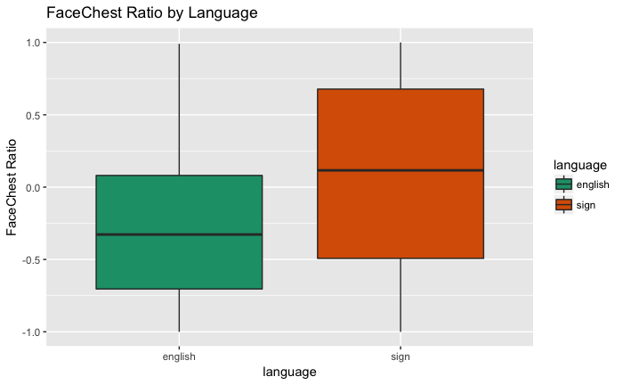

```r
ggplot(data_mid, aes(x = language, y = fcr, fill = language)) + geom_boxplot() + scale_fill_brewer(palette = "Dark2") + ylab("FaceChest Ratio") + ggtitle("FaceChest Ratio by Language")
```

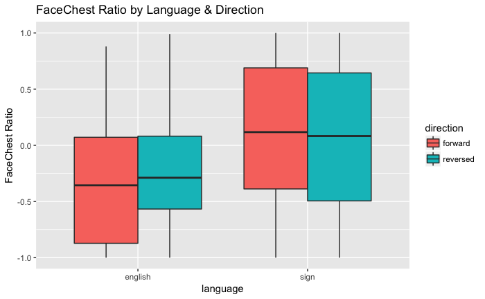

```r
ggplot(data_mid, aes(x = language, y = fcr, fill = direction)) + geom_boxplot() + ylab("FaceChest Ratio") + ggtitle("FaceChest Ratio by Language & Direction")
```

And Middle-Middle FaceChest Ratio here.

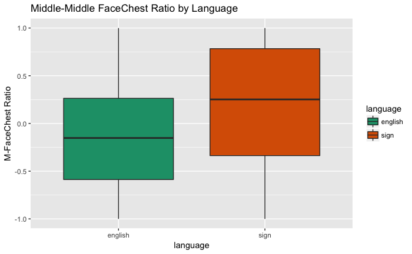

```r
ggplot(data_mid, aes(x = language, y = mfcr, fill = language)) + geom_boxplot() + scale_fill_brewer(palette = "Dark2") + ylab("M-FaceChest Ratio") + ggtitle("Middle-Middle FaceChest Ratio by Language")
```

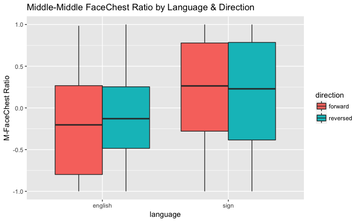

```r
ggplot(data_mid, aes(x = language, y = mfcr, fill = direction)) + geom_boxplot() + ylab("M-FaceChest Ratio") + ggtitle("Middle-Middle FaceChest Ratio by Language & Direction")
```